# Data Preparation

### General Information

This report is intended to help prepare your data. Additional fuctions for preparation are the following:

- p.numeric(dta): Lists numeric variables.
- p.continuous(dta, max_levels): Lists numeric continuous variables. Default for max_levels is .1 which restricts to numeric variables with 10% or more unique values.
- p.discrete(dta, max_levels): Lists numeric discrete variables. Default for max_levels is .1 which restricts to numeric variables with less than 10% unique values.
- p.integer(dta): Lists integer variables.
- p.character(dta): Lists character variables.
- p.unique(dta): Lists variables where every value is unique.
- p.factor(dta): Lists factor variables.
- p.asFactor(dta, columns): Converts variables to factors. Default for columns is any numeric discrete variables.
- p.replaceNull(dta, columns, null_value): Replaces null values for factor variables. The default null_value is “Missing”. Good to use in combination with p.factor().
- p.removeVariables(dta, columns): Removes variables from data set. Good to use in combination with p.unique().

#### Top row & bottom row sample of data

```r
head(data)
```

```
##   Survived Pclass    Sex Age SibSp Parch           Ticket    Fare   Cabin
## 1        0      3   male  22     1     0        A/5 21171  7.2500 Missing
## 2        1      1 female  38     1     0         PC 17599 71.2833     C85
## 3        1      3 female  26     0     0 STON/O2. 3101282  7.9250 Missing
## 4        1      1 female  35     1     0           113803 53.1000    C123
## 5        0      3   male  35     0     0           373450  8.0500 Missing
## 7        0      1   male  54     0     0            17463 51.8625     E46
##   Embarked Title CabinType TicketType
## 1        S    Mr   Missing        A/5
## 2        C   Mrs         C         PC
## 3        S  Miss   Missing   STON/O2.
## 4        S   Mrs         C    Missing
## 5        S    Mr   Missing    Missing
## 7        S    Mr         E    Missing
```

```r
tail(data)
```

```
##     Survived Pclass    Sex Age SibSp Parch          Ticket   Fare   Cabin
## 885        0      3   male  25     0     0 SOTON/OQ 392076  7.050 Missing
## 886        0      3 female  39     0     5          382652 29.125 Missing
## 887        0      2   male  27     0     0          211536 13.000 Missing
## 888        1      1 female  19     0     0          112053 30.000     B42
## 890        1      1   male  26     0     0          111369 30.000    C148
## 891        0      3   male  32     0     0          370376  7.750 Missing
##     Embarked Title CabinType TicketType
## 885        S    Mr   Missing   SOTON/OQ
## 886        Q   Mrs   Missing    Missing
## 887        S   Rev   Missing    Missing
## 888        S  Miss         B    Missing
## 890        C    Mr         C    Missing
## 891        Q    Mr   Missing    Missing
```

#### Data Structure

```r
str(data)
```

```
## 'data.frame':    714 obs. of  13 variables:
##  $ Survived  : Factor w/ 2 levels "0","1": 1 2 2 2 1 1 1 2 2 2 ...
##  $ Pclass    : Factor w/ 3 levels "1","2","3": 3 1 3 1 3 1 3 3 2 3 ...
##  $ Sex       : Factor w/ 2 levels "female","male": 2 1 1 1 2 2 2 1 1 1 ...
##  $ Age       : num  22 38 26 35 35 54 2 27 14 4 ...
##  $ SibSp     : Factor w/ 7 levels "0","1","2","3",..: 2 2 1 2 1 1 4 1 2 2 ...
##  $ Parch     : Factor w/ 7 levels "0","1","2","3",..: 1 1 1 1 1 1 2 3 1 2 ...
##  $ Ticket    : Factor w/ 681 levels "110152","110413",..: 524 597 670 50 473 86 396 345 133 617 ...
##  $ Fare      : num  7.25 71.28 7.92 53.1 8.05 ...
##  $ Cabin     : Factor w/ 149 levels "","A10","A14",..: 149 83 149 57 149 131 149 149 149 147 ...
##  $ Embarked  : Factor w/ 5 levels "","C","Q","S",..: 4 2 4 4 4 4 4 4 2 4 ...
##  $ Title     : Factor w/ 17 levels "Capt","Col","Don",..: 12 13 9 13 12 12 8 13 13 9 ...
##  $ CabinType : Factor w/ 10 levels "","A","B","C",..: 10 4 10 4 10 6 10 10 10 8 ...
##  $ TicketType: Factor w/ 44 levels "","A./5.","A.5.",..: 6 19 38 44 44 44 44 44 44 20 ...
```

#### Data Summary

Builds off of the describe() function.

```r
p.summary(data) #* represents factor variables.
```

```
##             vars   n distn distperc nulln       mean          sd   median
## Survived*      1 714     2    0.003     0   1.406162   0.4914599   1.0000
## Pclass*        2 714     3    0.004     0   2.236695   0.8382499   2.0000
## Sex*           3 714     2    0.003     0   1.634454   0.4819206   2.0000
## Age            4 714    88    0.123     0  29.699118  14.5264973  28.0000
## SibSp*         5 714     6    0.008     0   1.512605   0.9297835   1.0000
## Parch*         6 714     7    0.010     0   1.431373   0.8532894   1.0000
## Ticket*        7 714   542    0.759     0 336.389356 203.4331693 332.0000
## Fare           8 714   220    0.308     0  34.694514  52.9189295  15.7417
## Cabin*         9 714   135    0.189     0 130.764706  37.5484441 149.0000
## Embarked*     10 714     4    0.006     0   3.599440   0.7814825   4.0000
## Title*        11 714    17    0.024     0  11.214286   1.9045286  12.0000
## CabinType*    12 714     9    0.013     0   8.551821   2.5627011  10.0000
## TicketType*   13 714    39    0.055     0  37.852941  11.6799032  44.0000
##                trimmed       mad  min      max    range        skew
## Survived*     1.382867   0.00000 1.00   2.0000   1.0000  0.38133779
## Pclass*       2.295455   1.48260 1.00   3.0000   2.0000 -0.46657651
## Sex*          1.667832   0.00000 1.00   2.0000   1.0000 -0.55720993
## Age          29.269231  13.34340 0.42  80.0000  79.5800  0.38747440
## SibSp*        1.300699   0.00000 1.00   6.0000   5.0000  2.50900019
## Parch*        1.234266   0.00000 1.00   7.0000   6.0000  2.60792042
## Ticket*     335.618881 278.72880 1.00 681.0000 680.0000  0.04651291
## Fare         23.192672  12.20684 0.00 512.3292 512.3292  4.63409556
## Cabin*      140.510490   0.00000 2.00 149.0000 147.0000 -1.95796510
## Embarked*     3.744755   0.00000 2.00   5.0000   3.0000 -1.45804566
## Title*       11.416084   0.00000 1.00  17.0000  16.0000 -1.47890514
## CabinType*    9.057692   0.00000 2.00  10.0000   8.0000 -1.34875277
## TicketType*  40.534965   0.00000 2.00  44.0000  42.0000 -1.63992734
##                kurtosis         se nrow ncol
## Survived*   -1.85717669 0.01839242  714   13
## Pclass*     -1.42245668 0.03137071  714   13
## Sex*        -1.69188079 0.01803542  714   13
## Age          0.15976706 0.54364050  714   13
## SibSp*       6.95936533 0.03479627  714   13
## Parch*       8.74987659 0.03193355  714   13
## Ticket*     -1.29938517 7.61329502  714   13
## Fare        30.60539435 1.98044116  714   13
## Cabin*       2.47794095 1.40521520  714   13
## Embarked*    0.29079891 0.02924625  714   13
## Title*       3.44175075 0.07127519  714   13
## CabinType*   0.09633428 0.09590668  714   13
## TicketType*  1.11334860 0.43710939  714   13
```

#### Data Structure (Summary of Variables)

Numeric discrete lists any numeric variables where less than 10% of their data is unique.

```r
p.structure(data)
```

```
## All Variables
##  [1] "Survived"   "Pclass"     "Sex"        "Age"        "SibSp"
##  [6] "Parch"      "Ticket"     "Fare"       "Cabin"      "Embarked"
## [11] "Title"      "CabinType"  "TicketType"
## Unique Variables
## character(0)
## Numeric
## [1] "Age"  "Fare"
## Numeric Continuous
## [1] "Age"  "Fare"
## Numeric Discrete
## NULL
## Factors
##  [1] "Survived"   "Pclass"     "Sex"        "SibSp"      "Parch"
##  [6] "Ticket"     "Cabin"      "Embarked"   "Title"      "CabinType"
## [11] "TicketType"
## Integer
## NULL
## Character
## NULL
```

#### Table Summaries of Data

Table summary of all numeric discrete & factor variables with 100 or less distinct values. Builds off of the table() function. For a specific table summary of a variable use the table() function.

```r
p.table(data)
```

```
## Survived
##   0   1
## 424 290
##
## Pclass
##   1   2   3
## 186 173 355
##
## Sex
## female   male
##    261    453
##
## SibSp
##   0   1   2   3   4   5   8
## 471 183  25  12  18   5   0
##
## Parch
##   0   1   2   3   4   5   6
## 521 110  68   5   4   5   1
##
## Embarked
##               C       Q       S Missing
##       0     130      28     554       2
##
## Title
##         Capt          Col          Don           Dr     Jonkheer
##            1            2            1            6            1
##         Lady        Major       Master         Miss         Mlle
##            1            2           36          146            2
##          Mme           Mr          Mrs           Ms          Rev
##            1          398          108            1            6
##          Sir the Countess
##            1            1
##
## CabinType
##               A       B       C       D       E       F       G       T
##       0      12      45      51      31      30      11       4       1
## Missing
##     529
##
## TicketType
##                 A./5.       A.5.        A/4       A/4.        A/5
##          0          1          2          3          2          8
##       A/5.        A/S        A4.          C       C.A. C.A./SOTON
##          7          0          0          5         26          1
##         CA        CA.       F.C.     F.C.C.         Fa       P/PP
##          6          1          1          5          0          2
##         PC         PP  S.C./A.4. S.C./PARIS  S.O./P.P.     S.O.C.
##         50          3          0          2          2          5
##     S.O.P.       S.P.    S.W./PP         SC      SC/AH   SC/Paris
##          1          1          1          1          3          4
##   SC/PARIS      SCO/W       SO/C SOTON/O.Q.   SOTON/O2   SOTON/OQ
##          3          1          1          6          2          4
##     STON/O   STON/O2.      SW/PP      W./C.     W.E.P.        W/C
##         12          6          1          6          1          1
##       WE/P    Missing
##          2        525
```

#### Missing Data

The following graphs shows the distribution of missing values.

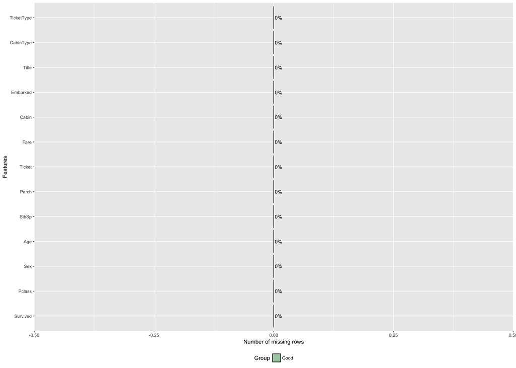

```r
DataExplorer::PlotMissing(data)
```

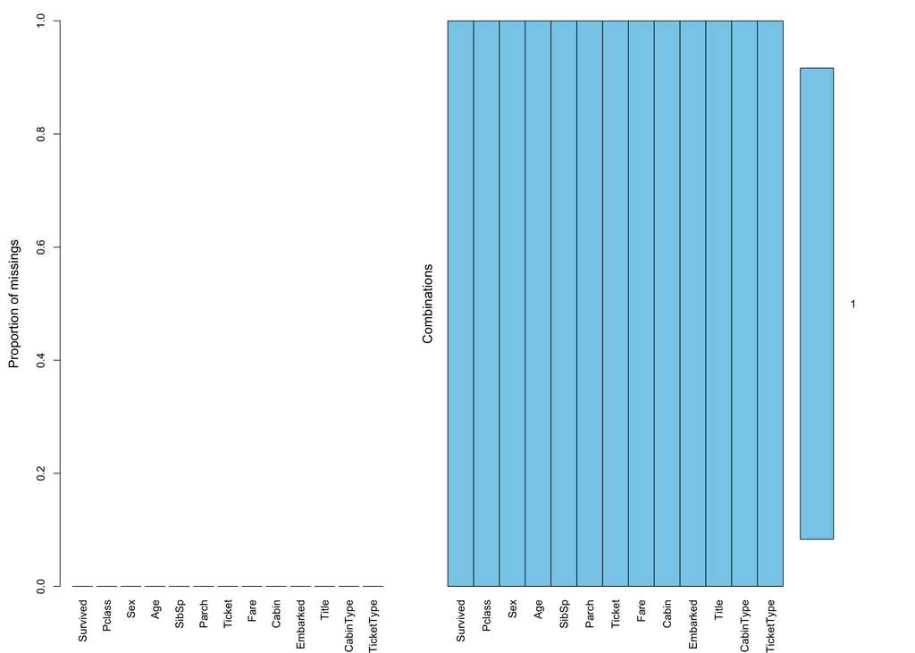

```r
VIM::aggr(data, numbers=TRUE)
```